# Probability prediction of firm fast growth

Viktoria Meszaros & Attila Serfozo

2021-02-11

## Abstract

In this project our goal is to build a firm success prediction model to help investment decisions. To achieve this we built a fast growth prediction model using probability prediction on detailed company data from a middle-sized country in the European Union. The data includes all registered companies from 2005-2016 in three selected industries (auto manufacturing, equipment manufacturing, hotels and restaurants). The prediction was built on several features such as key properties of companies, balance sheets and profit and loss statements, firm and management information. We looked at 7 different models including OLS, Lasso and Random forest and our final model was the OLS logit model using log sales and sales change variables with firm and financial statements variables. Overall the model predicted firm growth relatively good, its accuracy was 82.6% and it predicted 43.1% of the 2014 fast growth firms positive. The model RMSE was 0.354, the AUC was 0.688 and its average expected loss was 0.409.

Link to project [Github](https://github.com/Viki-Meszaros/CEU-Data-Analysis-3/tree/main/Assignment_2) repo.

## Introduction

The aim of this project was to build a firm success prediction model to help investment decisions using probability prediction on detailed company data from a middle-sized country in the European Union. In the exercise we considered a company successful if its sales grew by a compound annual growth rate (CAGR) of more than 30%. We calculated CAGR growth as the annualized average rate of sales growth between two given years, assuming growth takes place at an exponentially compounded rate. The prediction was built on several features including key company properties, balance sheet and profit and loss statement data and management information. During the project we looked at 7 different models including 5 OLS, a Lasso and a Random forest and in the end we desired to finish with a final model with relatively good prediction power regarding it’s RMSE, AUC and average expected loss.

## Data Preparation

The data set was constructed by Bisnode, a business data and analytics company (www.bisnode.com) and includes the detailed company data from a middle-sized country in the European Union. All registered companies are from 2005-2016 in three selected industries of auto manufacturing, equipment manufacturing, hotels and restaurants.

In the beginning of the data preparation we started with 287 829 observations (46 412 firms) and 48 variables describing all available information like properties of company, balance sheet, profit and loss elements and management information. The scope of the project was to build a model which can predict whether a company will be a successful firm or not. Thus, we decided to dedicate a company successful if its a fast growing company with 30% (CAGR) year-on-year sales growth.

We filtered our data set on the period between 2011 and 2014, we conducted the analysis for this time interval. We calculated CAGR of sales from 2012 to 2014 and created change of sales variable between 2011 to 2012. In addition we applied a logarithmic transformation on sales to achieve a normal distribution.

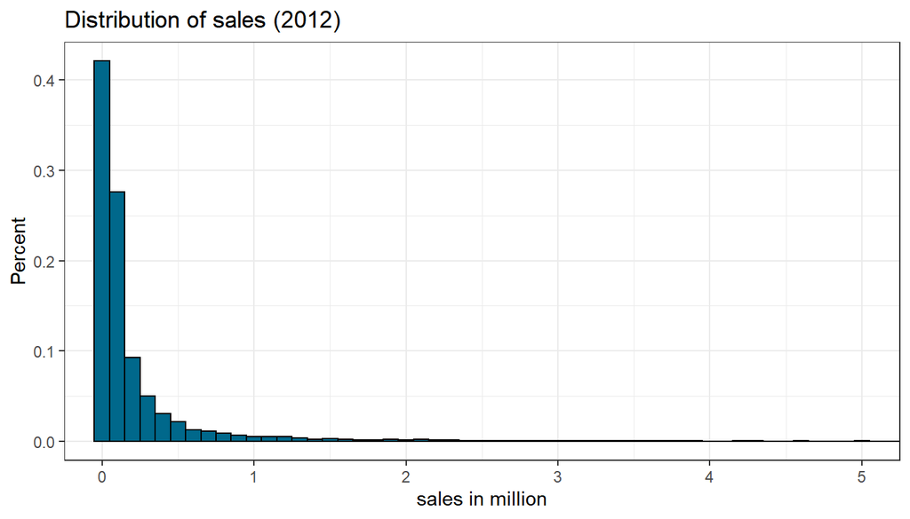

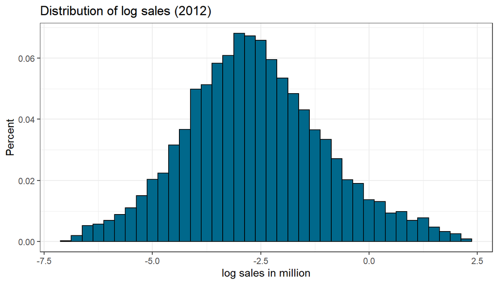

To create a proper analysis we filtered the dataset for companies with full balance sheet for these 4 years and with valid sales data. In the end we finished with 53 356 observations which we filtered down to the year of 2012 resulting 13 287 firms with data. The distribution of our key variable, CAGR growth, can be seen below.

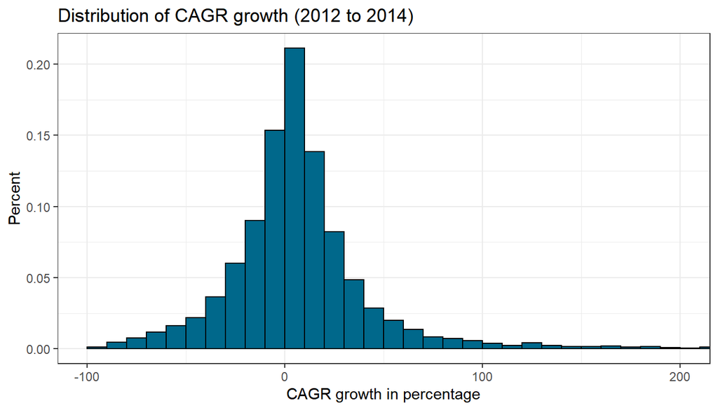

After creating our variable we wanted to predict, the next task was feature engineering. During this task we looked at financial variables and their validity. We flagged variables with mistakes in their balance sheet (e.g. negative values in assets) and created category variables and created factors. In the end we dropped observations with too many missing values in key variables and we finished with 116 variables and 11 910 observations.

Finally, for modeling purposes we separated the variables to 9 groups:

- **Raw variables:** our key variables for the prediction, such as main profit and loss and balance sheet elements.
- **Engine variables 1:** other profit and loss and balance sheet elements.
- **Engine variables 2:** quadratic transformation of some key variables, such as profit and loss, income before tax, extra profit and loss, share of equity. These variables are mostly between -1 and 1.
- **Engine variables 3:** flags of engine 2 variables.
- **D1:** variables measuring change of sales.
- **HR:** data about management such as age and gender of CEO or average labor number.
- **Firm:** properties of the firms, like age of the company, region, etc.
- **Interactions 1 and 2:** interactions of variables.

# Modelling

### Set up

| fast_growth_f | Number of companies | Percentage |
| --- | --- | --- |
| no_fast_growth | 9954 | 84% |
| fast_growth | 1956 | 16% |

Before started building and training models we divided the data set to a train and a holdout set. For this we randomly selected 20% of the observation to the holdout set, which we will use to evaluate of the performance of our last model with simulating the use of it on a unknown, live data. In the train data for each of the models we made a 5-fold cross validation, meaning that it will be divided 5 times to train and test sets.

### I. Probability logit models

We started our analysis with building 5 different logit models for the prediction. We used logit not linearity probability models as we wanted to make sure that are predictions will be between 0 and 1. The models we built contained different variables always increasing the complexity of them, with including additional variables, different functional forms or interactions. For the first two models we included arbitrarily chosen variables based on our domain knowledge of the topic. These were mainly sales, profit and loss and industry category of the firms. After this for each model we included more and more features.

|  | Variables |
| --- | --- |
| X1 model | Log sales + Log sales^2 + Change in Sales + Profit and loss + Industry |
| X2 model | X1 + Fixed assets + Equity + Current liabilities (and flags) + Age + Foreign management |
| X3 model | Log sales + Log sales^2 + Firm + Engine variables 1 + D1 |
| X4 model | X3 + Engine variables 2 + Engine variables 3 + HR |
| X5 model | X4 + Interactions 1 and 2 |

When comparing our models we looked at two important measures, the Root Mean Squared Error (RMSE) and the Area Under Curve (AUC) both averaged on the 5 different folds used during cross validation. We can see from the table below that the RMSE and AUC values are really similar for all of the models. The best model that had the lowest RMSE was the third one (X3) but the best model that has the highest AUC was the fourth one (X4). These two models outperformed all the others based on these criterion. We will consider the X3 model as a benchmark as it is much simpler with 35 predictors compared to the fourth model that has 75 predictors. In the third model we have all financial variables, firm specific details and some features related to the growth of sales from 2011 to 2012.

|  | Number.of.predictors | CV.RMSE | CV.AUC |
| --- | --- | --- | --- |
| X1 | 11 | 0.3602 | 0.6511 |
| X2 | 18 | 0.3564 | 0.6768 |
| X3 | 35 | 0.3550 | 0.6928 |
| X4 | 75 | 0.3551 | 0.6973 |
| X5 | 149 | 0.3563 | 0.6933 |

### II. LASSO model

After the basic logit models we also applied LASSO to and built a model that select the most important variables based on calculations and not like us manually deciding on what features to include and what not. In this model we included all the variables that we had in our fifth logit model (X5) - firm specific, all financial with all functional forms, growth related, some connected to HR and the interactions as well. We compared it to our benchmark. We can see that LASSO has shrunk some coefficients to zero ending up with 128 predictors (from 149 in the beginning). Based on the RMSE the LASSO model is slightly better but according to AUC values the simple third logit model (X3) is superior.

|  | Number.of.predictors | CV.RMSE | CV.AUC |
| --- | --- | --- | --- |
| X3 | 35 | 0.3550 | 0.6928 |
| LASSO | 128 | 0.3549 | 0.6747 |

### III. Random forest

After the logit and logit LASSO models we wanted to find out if we can build a stronger model with better predicting power if we use a random forest. It is a reasonable choice as it is good at finding non-linear patterns and interactions. In this model we used the same variables as in the fourth model (X4), but without any feature engineering. Meaning that we did not include polynomials, additional flag variables and winsorize values. In the tuning grid we used the default of growing 500 trees with 10 and 15 as the minimum number of observations at each terminal node and 5, 6 or 7 variables to use for each split. The random forest outperformed our best model, the X3 logit model, both in terms of lower RMSE with 0.352 and higher AUC with 0.707 values.

|  | CV.RMSE | CV.AUC |
| --- | --- | --- |
| X3 | 0.3550 | 0.6928 |
| Random_forest | 0.3529 | 0.7071 |

### ROC curve

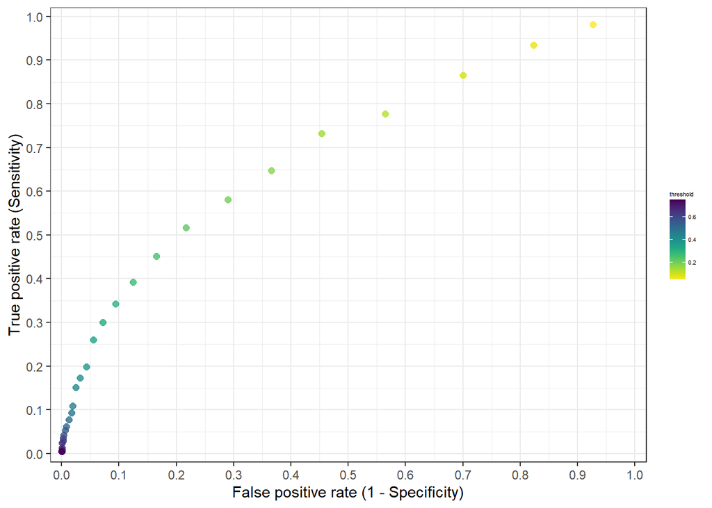

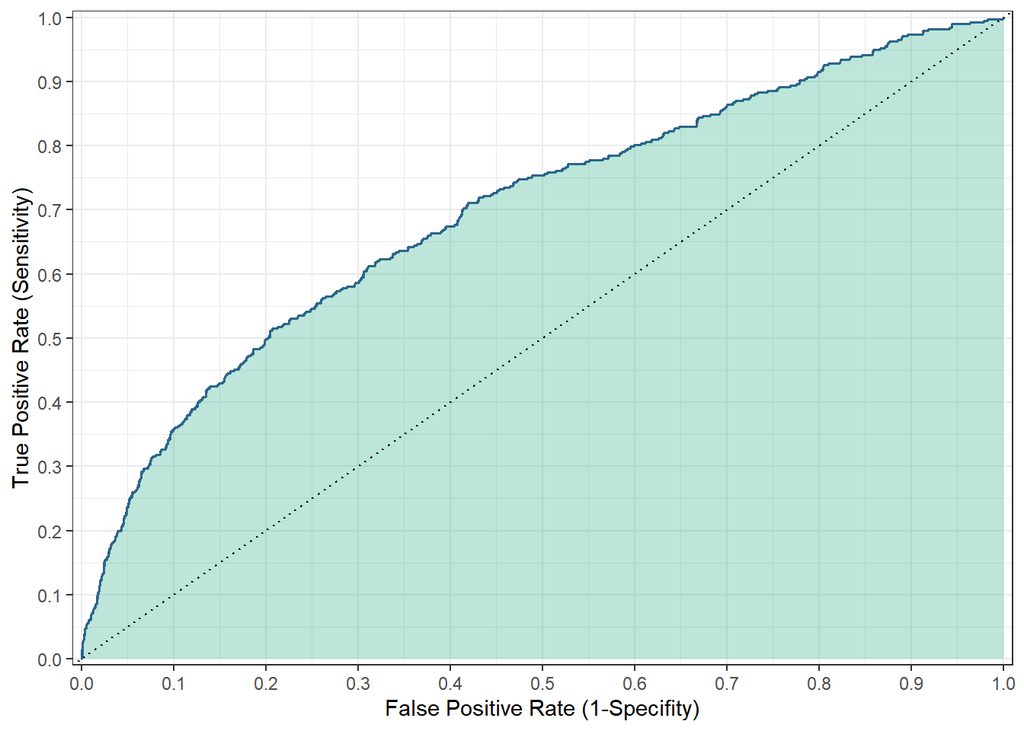

### Finding optimal threshold

To be able to find the optimal threshold we had to come up with a loss function for our problem. In this case the aim is to predict fast growth. Why we want to know that? Most probably as we want to invest in quickly growing companies to earn more. In this case when looking at the costs of errors it is worse for us if we make a False negative error, so we don’t invest in a company but it will grow significantly as we loose this good opportunity. On the other hand if we make a false positive error and we invest in a company but it is actually not a fast growing one, we don’t lose money it only increases with a slower phase. For these reasons we set in our loss function that the cost of a false negative error is **3 times more** than the cost of a false positive. Based on this we will be able to calculate the best threshold that minimizes our expected loss. Based on the formula the optimal classification threshold would be **1/(1+3) = 0.25**. To be more precise we ran the optimal threshold selection algorithm on the train data using the same 5-fold cross-validation as before. This is a more robust way of finding the optimal value. From the table below you can see that the formula and the algorithm gave a pretty similar threshold value, which is what we expected.The expected loss values are also really similar across the different models. The best (lowest) RMSE and the lowest expected loss belong to the same model, the random forest. For this the optimal threshold for classification is **0.297**. Overall all the best thresholds are close to the formula calculated one (0.24-0.3).

|  | Number.of.predictors | CV.RMSE | CV.AUC | CV.threshold | CV.expected.Loss |
| --- | --- | --- | --- | --- | --- |
| Logit X1 | 11 | 0.3602 | 0.6511 | 0.2812 | 0.4366 |
| Logit X3 | 35 | 0.3550 | 0.6928 | 0.2932 | 0.4128 |
| Logit LASSO | 128 | 0.3549 | 0.6747 | 0.2437 | 0.4338 |
| RF probability | 33 | 0.3529 | 0.7071 | 0.2967 | 0.4102 |

### Model choice

We decided on what model to use as the final model based on the expected losses. Here the lowest expected loss is for the random forest, then the probability logit model (X3) followed by the logit LASSO model and finally the most simple X1 logit model. Ordering the models based on AUC would yield the same list. RMSE shows a different order with random forest at the first place, then LASSO, logit X3, and the final model is again logit X1.

Even though the random forest was the best for all the comparison measures, we decided to use the simple Logit X3 probability model as our final choice. The numbers are really close to each other, but X3 is a much simpler model, having significantly less variables than the logit LASSO and it is easily interpretable compared to the random forest, which is a black box model.

### Model evaluation

- Accuracy is **82.6%**
- Sensitivity is **30.5%**
- Specificity is **92.4%**
- Correctly predicted positive **43.1%** (115/(115+152))

|  | no_fast_growth | fast_growth |
| --- | --- | --- |
| no_fast_growth | 1853 | 262 |
| fast_growth | 152 | 115 |

## Summary

The final model we choose for predicting if a company is a fast growth one or not was a probability logit model including features; log sales, firm specific variables, basic financial data and some indicators of growth. The accuracy of our model was 83% meaning that is classified 83% of the firms to the good category. From the actual not fast growing firms the model predicted 92% correctly, while from the actual fast growing ones it predicted 30% right. As the number of firms that are actually fast growing is much lower only 16% of our data, so it is more difficult to predict them then to predict non fast growing companies. From the firms the model predicted to be fast growing 43% actually turned out to be fast growing. The aim of this project was to help a company find the fast growth firms which worth investing in. Now based on our final model (in case of high external validity!) we can provide a tool for the company that predicts or suggests a pool of potentially fast growing firsms from which we can expect that 43% will be actually high growth. Based on the risk tolerance of the client we can change the loss function. For example if they are more sensitive to false positive errors, so do not want to predict that a company will grow fast when it actually won’t they will get totally different results. The number of falsely categorized firms to fast growth will decrease but in this case the number of companies that will be actually fast growth but categorized as not will increase. This would lead to that the sensitivity of our model will be lower, so it will be able to predict smaller amount of the fast growing firms correctly. This would be a more risk averse attitude.